# Reproducible Report Template

Project 2

# 1 Executive Summary

- The aim of this report is to investigate the effects of Covid-19 on traffic volume through the cross-city tunnel in Sydney. These two research questions were proposed because since it is a toll road, the number of vehicles that passes affect the profits made. Furthermore, it shall be noted that trucks pay a significant higher price than cars (NSW Government, 2023).
- The main discoveries are that there is a great statistical significance in difference between the volume of traffic between 2019 and 2020 because of Covid-19. Furthermore, there is always a greater proportion of cars passes through the cross-city tunnel compared to trucks.

# 2 Full Report

## 2.1 Initial Data Analysis (IDA) Source

- The data came from the NSW Toll Road Data. However, it shall be noted that the source of the data is provided by a private company Transurban.
- The data is valid because: “Undertaking accepted by the ACCC on 29 August 2018 under section 87B of the Competition and Consumer Act 2010 (Cth) (Undertaking). (ACCC, 2018)”. There it has an obligation to publish accurate traffic data on a quarterly basis.
- Possible issues includes:  
  It shall be noted that the data is provided in 2019 and 2020, and during a period of 2020 there were several lockdowns due to the pandemic. Therefore, this anomaly reduces the amount of traffic on the roads within NSW. Possible effects may happen on the result of the analysis when using the year 2020 for modelling traffic.

Another issue is with regards to data is that it is only provided from toll roads and many commuters may choose various other forms of transportation such as not using toll roads, using public transport or biking. Therefore, this data is not representative of the population and may provide a false analysis of the overall traffic flow.

- Potential stakeholders include:  
  Civil engineering who modelling traffic.  
  Daily commuters who want to avoid traffic.  
  Governments who might want to understand traffic to minimize traffic congestion or sway more public policy support public transport.  
  Private companies who might want to invest into infrastructure in Australia.

## 2.2 Initial Data Analysis (IDA) Data

- The data set contains 14 variables, however the key is to notice that the data splits the amount of cars and trucks that pass through each gate in 15 minute intervals. The gates are located at the cross-city tunnel in Sydney where the 3 gates are Mainline Eastbound, Sir John Young, Mainline Westbound.
- The key variables that will be used in this analysis are the “Date”, “Vehicle Class” and the “TotalVolume”.

**“Date”** is in the format day/month/year where it contains all months of March in 2019 and 2020  
**“Vehicle Class”** represents weather the vehicle is a truck or car. Furthermore in our report we let 1 be cars and 0 be trucks **“TotalVolume”** represents the number of cars or trucks that passes through the cross city tunnel in 15 minute intervals.

```r
## read in data
data <- read.csv("data/traffic.csv")
## show classification of variables
str(data)
```

```
## 'data.frame':    35712 obs. of  14 variables:
##  $ s                 : chr  "CCT" "CCT" "CCT" "CCT" ...
##  $ FinancialQtrID    : int  201903 201903 201903 201903 201903 201903 201903 201903 201903 201903 ...
##  $ Date              : chr  "1/03/2019" "1/03/2019" "1/03/2019" "1/03/2019" ...
##  $ IntervalStart     : chr  "0:00" "0:00" "0:00" "0:00" ...
##  $ IntervalEnd       : chr  "0:14" "0:14" "0:14" "0:14" ...
##  $ Version           : int  1 1 1 1 1 1 1 1 1 1 ...
##  $ VehicleClass      : chr  "Car" "Truck" "Car" "Truck" ...
##  $ X                 : chr  "East" "East" "SJY" "SJY" ...
##  $ GantryDirection   : chr  "E" "E" "N" "N" ...
##  $ GantryLocation    : chr  "Mainline Eastbound" "Mainline Eastbound" "Sir John Young" "Sir John Young" ...
##  $ GantryGPSLatitude : num  -33.8 -33.8 -33.8 -33.8 -33.8 -33.8 -33.8 -33.8 -33.8 -33.8 ...
##  $ GantryGPSLongitude: num  151 151 151 151 151 ...
##  $ GantryType        : chr  "Mainline Gantry" "Mainline Gantry" "Ramp Gantry" "Ramp Gantry" ...
##  $ TotalVolume       : int  23 2 10 0 18 2 21 1 6 0 ...
```

## 2.3 Research Question 1: Is there a significant effect on traffic due to the effects of Covid-19

By plotting both 2019 and 2020’s total volume of traffic that flows through the cross city-tunnel it shows an interesting result. There is a periodic trend in the total amount of cars that pass through the tunnel throughout the month. By looking at the local maxima and minima we notice that every Friday there is an increase in the total amount and Sunday there is dip in total amount of traffic. In the year 2020, this trend is the same with the maxima and minima. This shows that over a period of a week there is a cyclical repeating pattern that happens. However, it shall be noted March 1st in 2019 starts on a Friday and March 1st in 2020 starts on a Sunday. Furthermore, there is a general decreasing trend for the year 2020 and this caused by the severity of Covid-19

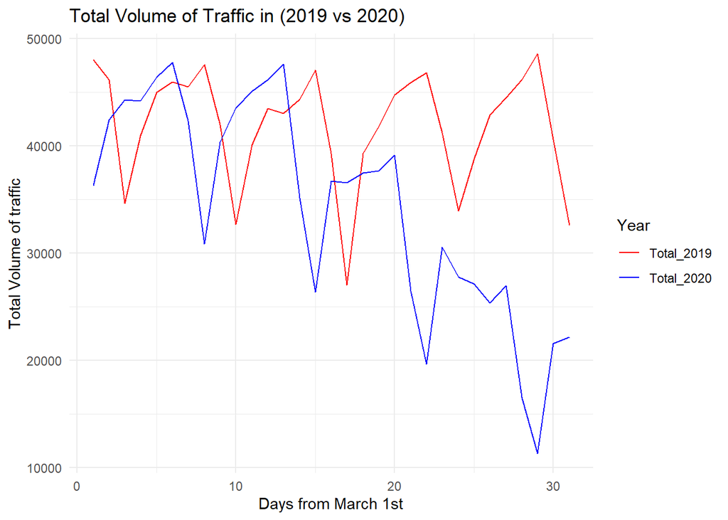

```r
library(ggplot2)

# Read the CSV file
data <- read.csv("data/traffic.csv")
data$Date <- as.Date(data$Date, format = "%d/%m/%Y")

data_2019 <- subset(data, format(as.Date(Date), "%Y") == 2019)
data_2020 <- subset(data, format(as.Date(Date), "%Y") == 2020)

daily_totals_2019 <- aggregate(TotalVolume ~ Date, data_2019, sum)
daily_totals_2020 <- aggregate(TotalVolume ~ Date, data_2020, sum)

daily_totals <- data.frame()

for (i in 1:nrow(daily_totals_2019)) {
  new_row <- data.frame(Day = i,
                        Year = "Total_2019",
                        TotalVolume = daily_totals_2019$TotalVolume[i])
  daily_totals <- rbind(daily_totals, new_row)
}

for (i in 1:nrow(daily_totals_2020)) {
  new_row <- data.frame(Day = i,
                        Year = "Total_2020",
                        TotalVolume = daily_totals_2020$TotalVolume[i])
  daily_totals <- rbind(daily_totals, new_row)
}

ggplot(daily_totals, aes(x = Day, y = TotalVolume, color = Year)) +
  geom_line() +
  labs(x = "Days from March 1st", y = "Total Volume of traffic", title = "Total Volume of Traffic in (2019 vs 2020)") +
  scale_color_manual(values = c("red", "blue")) +
  theme_minimal()
```

To test the statistical significance of the difference in the volume of traffic due to the effects of Covid-19 a one sample t-test will be used

**Significance Level**  
By convention, let the significance level be alpha = 0.05

**Hypothesis**  
From the previous discussion, it is known that different days of the week is a confounder. Therefore the report will compare the difference between the first Sundays of the month instead of the 1st days.

```r
daily_total_by_week_2019 <- data.frame()
# offset since Friday is that starting day
for (i in 1:nrow(daily_totals_2019)) {
  new_row <- data.frame(Day = 1 + ((i+3) %% 7),
                        TotalVolume = daily_totals_2019$TotalVolume[i])
  daily_total_by_week_2019 <- rbind(daily_total_by_week_2019, new_row)
}

daily_total_by_week_2020 <- data.frame()
# offset since Sunday starting date
for (i in 1:nrow(daily_totals_2020)) {
  new_row <- data.frame(Day = 1 + ((i+5) %% 7),
                        TotalVolume = daily_totals_2020$TotalVolume[i])
  daily_total_by_week_2020 <- rbind(daily_total_by_week_2020, new_row)
}

daily_total_by_week_2019 <- daily_total_by_week_2019[-c(1, 2), ]
daily_total_by_week_2020 <- daily_total_by_week_2020[-c(30, 31), ]

difference = daily_total_by_week_2019$TotalVolume - daily_total_by_week_2020$TotalVolume
```

H0: mean difference in the volume of traffic is 0 H1: mean of different in the volume of traffic is not 0

**Assumptions** - There is independence in the samples. Therefore, today’s volume of traffic through the cross-city tunnel shouldn’t affect tomorrows. - The sample follows a normal distribution

Comparing the box plot, the sample about normally distributed.

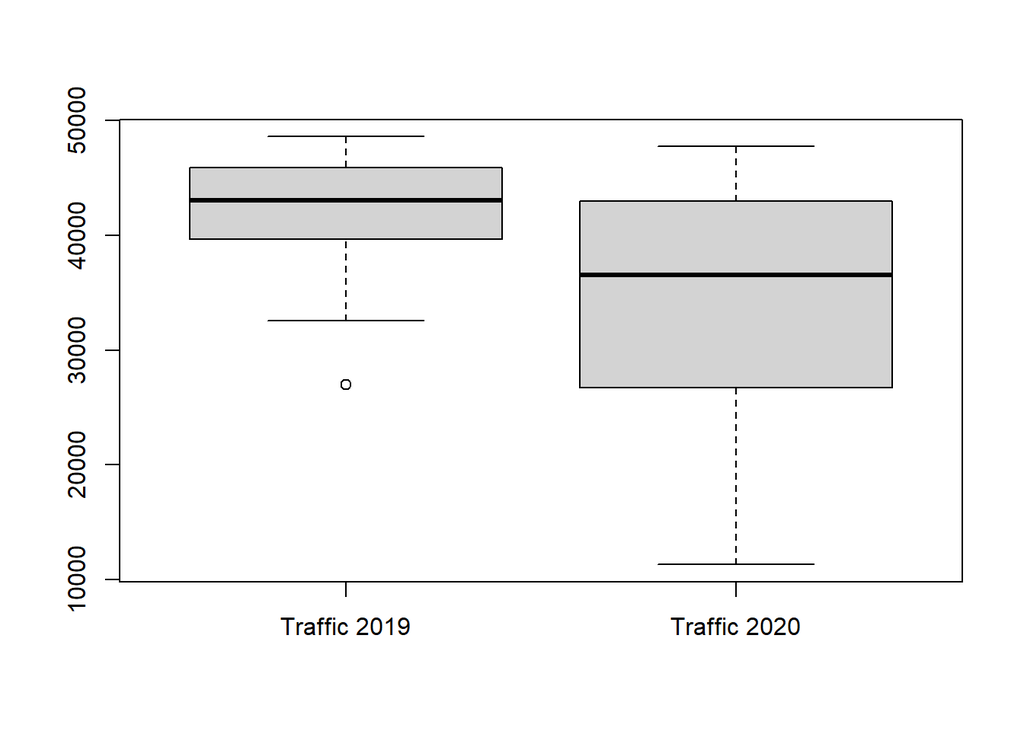

```r
boxplot(daily_totals_2019$TotalVolume, daily_totals_2020$TotalVolume, names = c("Traffic 2019", "Traffic 2020"))
```

**Test Statistics**

```r
OV = mean(difference)
# expect a value of 0
EV = 0
# we are not using the population SD anymore since we removed values from the days of march in 2019 and 2020
SE = sd(difference) / sqrt(length(difference))

TS = (OV - EV) / SE
# 2 sided test
cbind(TS)
```

```
##            TS
## [1,] 4.158162
```

**P-value**

```r
p_value = 2 * pt(TS, df = length(difference) -2, lower.tail=FALSE)
cbind(p_value)
```

```
##           p_value
## [1,] 0.0002908963
```

**Conclusion** As our p-value is much smaller than our significance level of alpha = 0.05, we have sufficient evidence to reject our null hypothesis. Therefore, the impacts of Covid-19 has had a significant effect on the volume of traffic in Sydney passing through the cross-city tunnel. Furthermore, this emphasizes on the conclusion reached in line graph at start of the report.

## 2.4 Additional Research

“During 2020, the smallest declines were around 9% – in the Sydney region due to strict, timely lock downs allowing subsequent fast reopening” (Fitch Ratings, 2022). However, it must be noted that although the methodology of finding the statistical results is not known, it should be taken with credit since Fitch Ratings are one of the “big three” credit rating companies. Hence comparing our results, this report agrees with our analysis and suggests that during 2020 there was a decline in traffic volume in Sydney.

## 2.5 Research Question 2: Is there still a greater proportion of cars compared to trucks that pass through the cross city tunnel in March 2020 given Covid-19 restrictions.

$$p(cars) = \frac{cars}{cars +trucks}$$

```r
## write code here
p_cars = (29217268 + 49962427 + 53614038) / (29217268 + 49962427 + 53614038 + 216159 + 1133952 + 1086443)
p_cars
```

```
## [1] 0.9819822
```

Furthermore, by convention, let the significance level be alpha = 0.05

**Assumptions**  
The underlying assumption in this analysis is that. - There is independence in the samples. Therefore, the cars that passes through each day should not affect the number of trucks that passes through the cross-city tunnel. - There is random sampling of data where the cars and trucks picked are representative of the population. - The data will follow a normal distribution

Assuming p = 0.9819822, we have the following for the binary box model: (let 1 be cars and 0 be trucks).

Theoretically out of 1000 cars, the expected value and the standard error in our predictions are.

```r
mu = p_cars
sigma = (1 - 0) * sqrt(p_cars * (1 - p_cars))
cbind(mu, sigma)
```

```
##             mu     sigma
## [1,] 0.9819822 0.1330157
```

Furthermore we define out of 1000 cars, what is the expected value of cars and the standard error in our predictions.

```r
n = 1000
EV_sum = mu * n
SE_sum = sigma * sqrt(n)
cbind(EV_sum, SE_sum)
```

```
##        EV_sum   SE_sum
## [1,] 981.9822 4.206325
```

```r
EV_mean = mu
SE_mean = sigma / sqrt(n)
cbind(EV_mean, SE_mean)
```

```
##        EV_mean     SE_mean
## [1,] 0.9819822 0.004206325
```

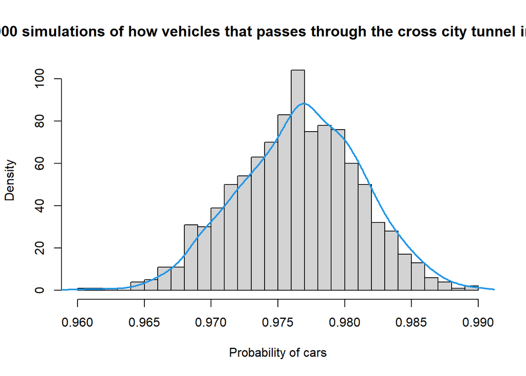

```r
set.seed(1)
data_cars_2020 <- subset(data, VehicleClass == "Car")
data_trucks_2020 <- subset(data, VehicleClass == "Truck")

cars_2020 <- sum(data_cars_2020$TotalVolume)
trucks_2020 <- sum(data_trucks_2020$TotalVolume)

box_model <- rep(c(0, 1), times = c(trucks_2020, cars_2020))

sim.est.without = 0
nsim = 1000
for (j in 1:nsim) {
  samp.without = sample(box_model, size = 1000, replace = FALSE)
  sim.est.without[j] = mean(samp.without)
}

data_plot_box <- data.frame(Value = sim.est.without)

hist(sim.est.without, pr = T, breaks = "fd", main="1000 simulations of how vehicles that passes through the cross city tunnel in 2020", xlab="Probability of cars",freq=F)
lines(density(sim.est.without), col = 4, lwd = 2)
```

The following measures the different between the simulated results and the expected value.

```r
OV = sample(box_model, size = 1000, replace = FALSE)

TS_sum = (sum(OV) - EV_sum) / SE_sum
TS_mean = (mean(OV) - EV_mean) / SE_mean
cbind(TS_sum, TS_mean)
```

```
##         TS_sum   TS_mean
## [1,] -1.422188 -1.422188
```

**P-value**

```r
p_value = pnorm(TS_sum, lower.tail = F)
cbind(p_value)
```

```
##        p_value
## [1,] 0.9225142
```

# 3 References

Australian Competition and Consumer Commission. (2018). Section 87B undertakings register. https://www.accc.gov.au/public-registers/undertakings-registers/section-87b-undertakings-register

Butterworth, N. (2022). Exploring Sydney Toll Road Data. https://informatics.sydney.edu.au/news/sydneytolls/https://informatics.sydney.edu.au/news/sydneytolls/

Fitch Ratings. (2022). Global Toll Road Traffic Tracker: 4Q21 Update. Fitch Rating Cases. https://www.fitchratings.com/research/infrastructure-project-finance/global-toll-road-traffic-tracker-4q21-update-10-02-2022

New South Wales Government. (2023). Toll costs by road. https://www.nsw.gov.au/driving-boating-and-transport/tolling/toll-costs-by-road